# TP_5

2024-04-19

# 1) Création d’une série temporelle

## a) Chargement des modules

```r
library("weathercan")
library("tidyverse")
library("lubridate")
library("tsibble")
library("fable")
library("fpp3")
```

```r
library("ggplot2")
library("dplyr")
library("forecast")
library("readxl")
library("cowplot")
```

## b) Transformation des données

D’abord, on doit transformer la colonne « time » qui est de type numérique, et dans laquelle les dates sont des nombres réels au format : date. On extrait l’année entière de la colonne « time » dans la variable « year » et la partie décimale de la colonne “time” représentant les mois dans « month_decimal ».Ensuite, on convertit cette partie décimale en mois en multipliant par 12 et en ajoutant 1, puis en arrondissant. Enfin, on transforme le tout en un objet date, puis on reformate cette date en une chaîne de caractères au format “année-mois”.

```r
hawai <- read_excel("C:/Users/DELL/Desktop/Cours/Modélisation des agrosystemes/TP5_Aissi/hawai.xlsx")
hawai <- hawai %>%
  mutate(year = floor(time),
         month_decimal = time - year,
         month = round((month_decimal * 12) + 1),
         time = format(as.Date(paste(year, month, "01", sep = "-")), "%Y-%m"))
hawai <- hawai %>%
  select(time, CO2)
head(hawai)
```

| time | CO2 |
| --- | --- |
| 1958-03 | 316.1000 |
| 1958-04 | 317.2000 |
| 1958-05 | 317.4333 |
| 1958-06 | 317.4333 |
| 1958-07 | 315.6250 |
| 1958-08 | 314.9500 |

```r
hawai_ts <-hawai|>
    mutate(Month=yearmonth(time))|>
    as_tsibble(index=Month)|>
    select(Month, CO2)
head(hawai_ts)
```

| Month | CO2 |
| --- | --- |
| 1958 mars | 316.1000 |
| 1958 avr. | 317.2000 |
| 1958 mai | 317.4333 |
| 1958 juin | 317.4333 |
| 1958 juil. | 315.6250 |
| 1958 août | 314.9500 |

## c) Visualisation

On visualise les tendances cycliques avec feasts::gg_season() et feasts::gg_subseries().

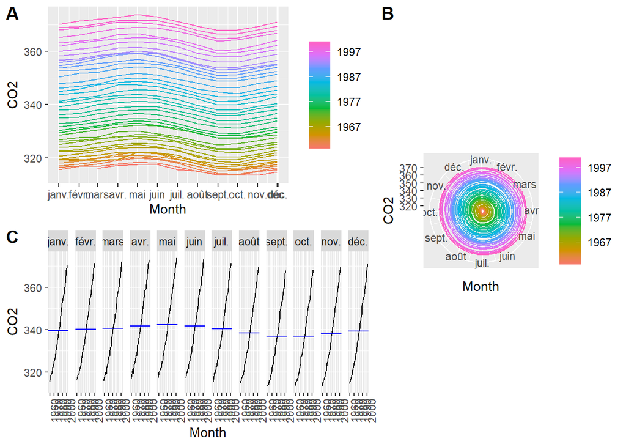

```r
ggA <- hawai_ts |>
  gg_season(`CO2`) + xlab("Month")
ggB <- hawai_ts |>
  gg_season(`CO2`, polar = TRUE) + xlab("Month")
ggC <- hawai_ts |>
  gg_subseries(`CO2`) + xlab("Month")
left_col <- plot_grid(ggA, ggC, labels = c('A', 'C'), ncol = 1)
plot_grid(left_col, ggB, labels = c('', 'B'),
          ncol = 2, rel_widths = c(1.5, 1))
```

On remarque une légère oscillation des valeurs de CO2 entre les mois, et une tendance croissante au fil des années.

# 2) Séparation de la série en parties d’entraînement et en partie test

On calcule l’index de séparation entre les données d’entraînement et de test, puis on extrait les premières lignes de l’ensemble de données jusqu’à l’index de séparation calculé, créant ainsi l’ensemble de données d’entraînement, le reste étant les données de test.

```
## Plot variable not specified, automatically selected `.vars = CO2`
## Plot variable not specified, automatically selected `.vars = CO2`
```

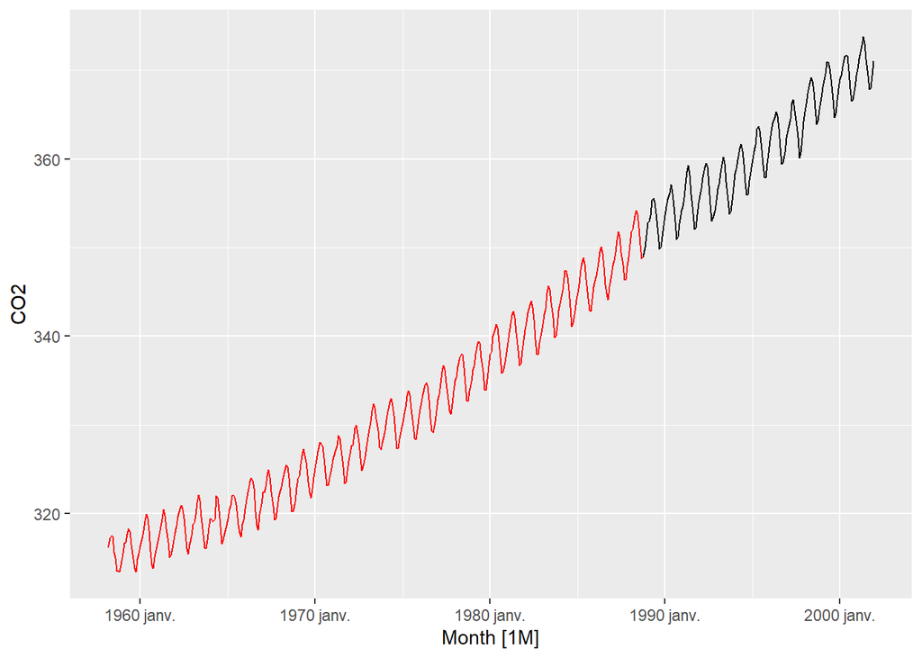

```r
prop_train<- 0.7
split_index <- floor(nrow(hawai_ts) * prop_train)
train_data <- hawai_ts[1:split_index, ]
test_data <- hawai_ts[(split_index + 1):nrow(hawai_ts), ]
autoplot(hawai_ts) +
  autolayer(train_data,colour = "red")
```

# 3) Création des modèles prévisionnels et analyse des résidus

## a) Méthode SNAIVE

```
## Plot variable not specified, automatically selected `.vars = .fitted`
## Plot variable not specified, automatically selected `.vars = CO2`
```

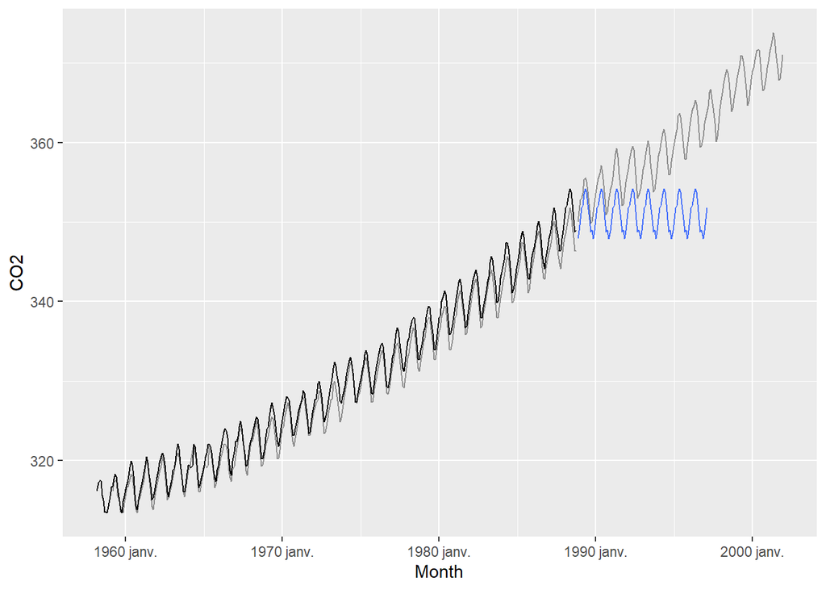

```r
CO2_fit <- train_data |>
  model(SNaive = SNAIVE(`CO2`))
CO2_fc <- CO2_fit |> forecast(h = 100)
CO2_fc |>
  autoplot(train_data, level = NULL) +
  autolayer(fitted(CO2_fit), alpha = 0.4)+
  autolayer(test_data, alpha = 0.4)
```

Puisque dans la méthode SNAIVE, la valeur prédite est celle provenant du cycle précédent, les prédictions n’ont pas pris en compte la tendance croissante des autres cycles à travers les années. Le même cycle est alors en train de se répéter, et la prévision aura peu d’intérêt.

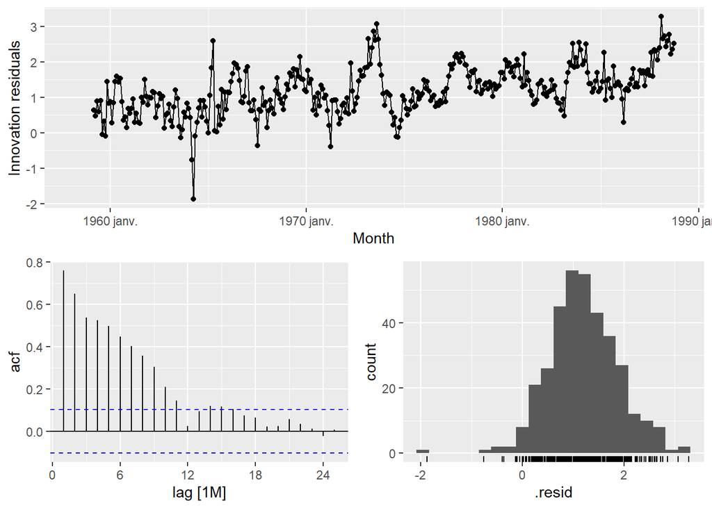

```r
gg_tsresiduals(CO2_fit)
```

On remarque une très forte autocorrélation dans le graphique « acf ». Voyons maintenant les tests statistiques de Shapiro et de Ljung-box :

```r
CO2_res <- CO2_fit |>
  augment()
CO2_res |>
  features(.innov, ljung_box, lag = 19)
```

| .model | lb_stat | lb_pvalue |
| --- | --- | --- |
| SNaive | 913.5249 | 0 |

```r
shapiro.test(CO2_res$.innov)
```

```
##
##  Shapiro-Wilk normality test
##
## data:  CO2_res$.innov
## W = 0.99012, p-value = 0.01695
```

```r
accuracy(CO2_fc, hawai_ts)
```

| .model | .type | ME | RMSE | MAE | MPE | MAPE | MASE | RMSSE | ACF1 |
| --- | --- | --- | --- | --- | --- | --- | --- | --- | --- |
| SNaive | Test | 6.24515 | 7.070092 | 6.24515 | 1.739891 | 1.739891 | 5.112678 | 5.143114 | 0.9482899 |

L’évaluation du modèle effectuée avec la fonction fabletools::accuracy() donne aussi des erreurs très élevées. Le modèle prévisionnel par SNAIVE n’est alors pas alors approprié.

# b) Méthode SES avec tendance

On peut laisser R optimiser notre choix avec le modèle ETS par défaut (error, tend and seasonnal). L’optimisation est lancée avec la fonction fable::ETS(), sans utiliser les paramètres.

```r
CO2_model <- train_data |>
  model(ETS(`CO2`))
report(CO2_model)
```

```
## Series: CO2
## Model: ETS(A,A,A)
##   Smoothing parameters:
##     alpha = 0.6802687
##     beta  = 0.00225957
##     gamma = 0.0001015036
##
##   Initial states:
##      l[0]     b[0]      s[0]       s[-1]      s[-2]     s[-3]     s[-4]
##  314.5366 0.112694 0.5563618 -0.08727554 -0.9497972 -2.004136 -3.056502
##      s[-5]     s[-6]   s[-7]    s[-8]    s[-9]   s[-10]   s[-11]
##  -2.878968 -1.183077 0.78395 2.259468 2.856629 2.384125 1.319221
##
##   sigma^2:  0.114
##
##      AIC     AICc      BIC
## 1392.687 1394.436 1459.125
```

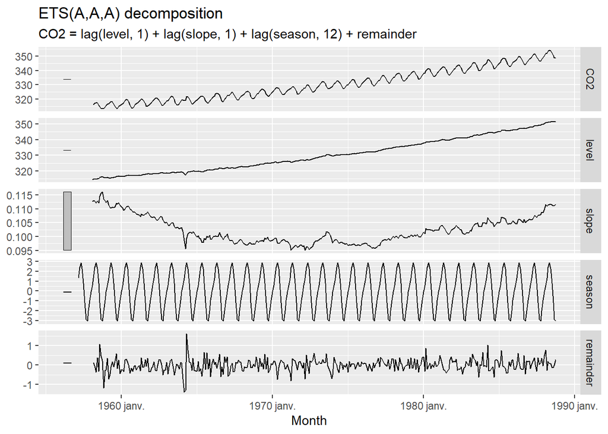

```r
components(CO2_model) |>
  autoplot()
```

Le modèle ajusté est de type ETS (A, A, A), où : “A” représente une composante d’erreur additive pour chacune des tendances, saison, et erreur. Dans un modèle avec tendance et saisonnalité additive, les données « levels » sont additionnées aux les données « season » pour obtenir la prévision.

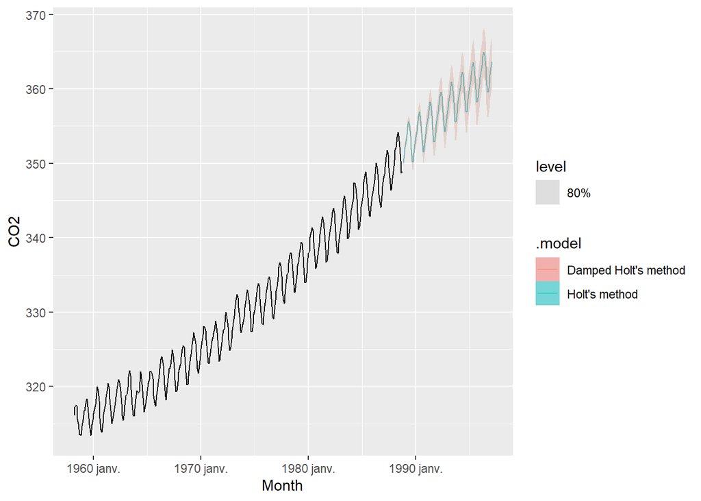

```r
CO2_holt <- train_data |>
  model(
    `Holt's method` = ETS(CO2 ~ error("A") +
                            trend("A") + season("A")),
    `Damped Holt's method` = ETS(CO2 ~ error("A") +
                                   trend("A") + season("A"))
  )
CO2_holt |>
  forecast(h = 100) |>
  autoplot(train_data, level = 80, alpha = 0.5)
```

```r
tidy(CO2_holt)
```

| .model | term | estimate |
| --- | --- | --- |
| Holt's method | alpha | 6.802687e-01 |
| Holt's method | beta | 2.259570e-03 |
| Holt's method | gamma | 1.015036e-04 |
| Holt's method | l[0] | 3.145366e+02 |
| Holt's method | b[0] | 1.126940e-01 |
| Holt's method | s[0] | 5.563618e-01 |
| Holt's method | s[-1] | -8.727554e-02 |
| Holt's method | s[-2] | -9.497972e-01 |
| Holt's method | s[-3] | -2.004136e+00 |
| Holt's method | s[-4] | -3.056502e+00 |

[output cut: 24 more lines]

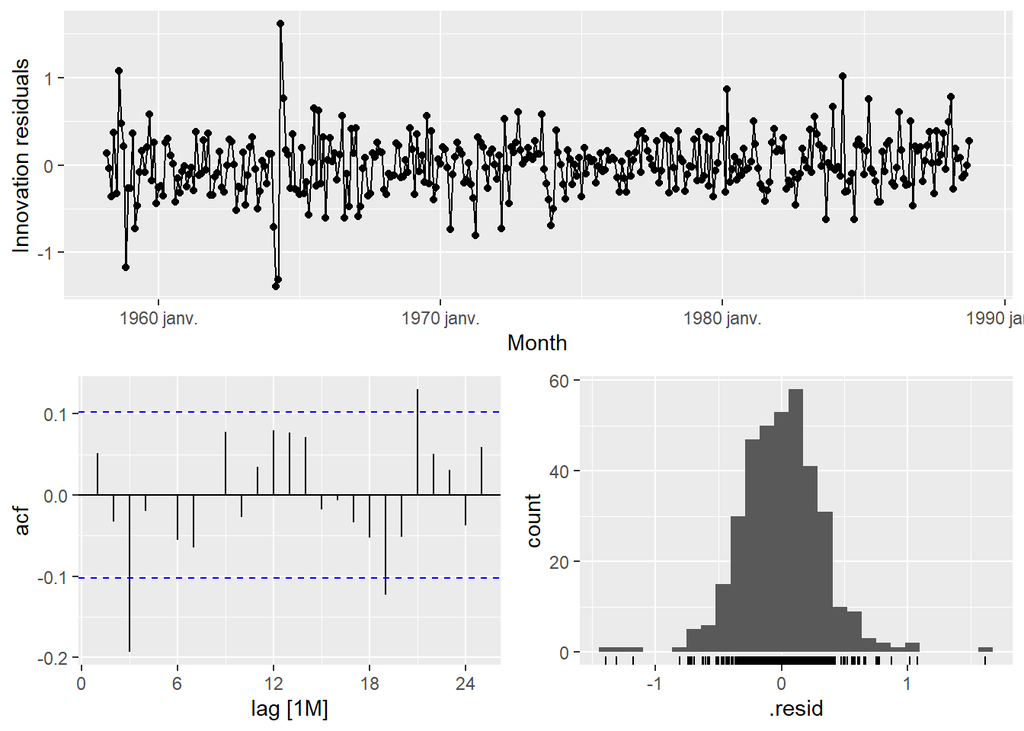

```r
gg_tsresiduals(CO2_model)
```

```r
CO2_res <- CO2_holt |>
  augment()
CO2_res |>
  features(.innov, ljung_box, lag = 19)
```

| .model | lb_stat | lb_pvalue |
| --- | --- | --- |
| Damped Holt's method | 35.40014 | 0.01249449 |
| Holt's method | 35.40014 | 0.01249449 |

```r
shapiro.test(CO2_res$.innov)
```

```
##
##  Shapiro-Wilk normality test
##
## data:  CO2_res$.innov
## W = 0.96899, p-value = 2.231e-11
```

La p-value étant de 2.231e-11,on peut conclure qu’il est peu probable que les résidus forment un bruit blanc, et que les données ne suivent pas une distribution normale. Les résidus contiennent de l’autocorrélation, ce qui devrait être évité. Ceci est toutefois dû aux points allant au-delà du seuil de 0.1 et de -0.1, que l’on peut observer sur le graphique d’autocorrélation. De plus, le graphique de la distribution des résidus montre des valeurs aberrantes, ainsi qu’une distribution plutôt pointue, qui donnerait un test de Kurtosis probablement élevé.

```r
library(moments)
kurtosis_value <- kurtosis(CO2_res$.innov, na.rm = TRUE)
print(kurtosis_value)
```

```
## [1] 5.835065
```

En effet, la valeur kurtosis est de 5.83 (>3), ce qui indique que les données sont plus pointues que la distribution normale.

```r
accuracy(CO2_model)
```

| .model | .type | ME | RMSE | MAE | MPE | MAPE | MASE | RMSSE | ACF1 |
| --- | --- | --- | --- | --- | --- | --- | --- | --- | --- |
| ETS(CO2) | Training | -0.001062961 | 0.330219 | 0.2482782 | -0.000786347 | 0.07547246 | 0.2032564 | 0.2402167 | 0.05170149 |

Les erreurs sont plutôt faible (Surtout RMSE qui est proche de 0). Le modèle ETS(CO2) semble alors avoir des performances acceptables en termes de précision.